# Exploratory Data Analysis of Red Wine dataset by Kriti Singh

# Bivariate Plots Section

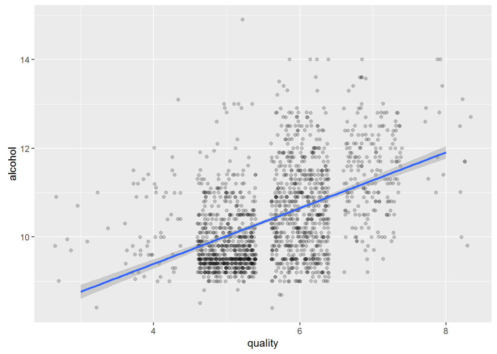

[output not shown]

The scatter plot between quality of wine and alcohol content tells us something about their correlation. The high quality alcohol seems to have more alcohol content. Moreover, the correlation coefficient is 0.48 which is strongest of all correlations with quality. The linear fit also shows a positive trend in the plot.

Let’s try boxplot

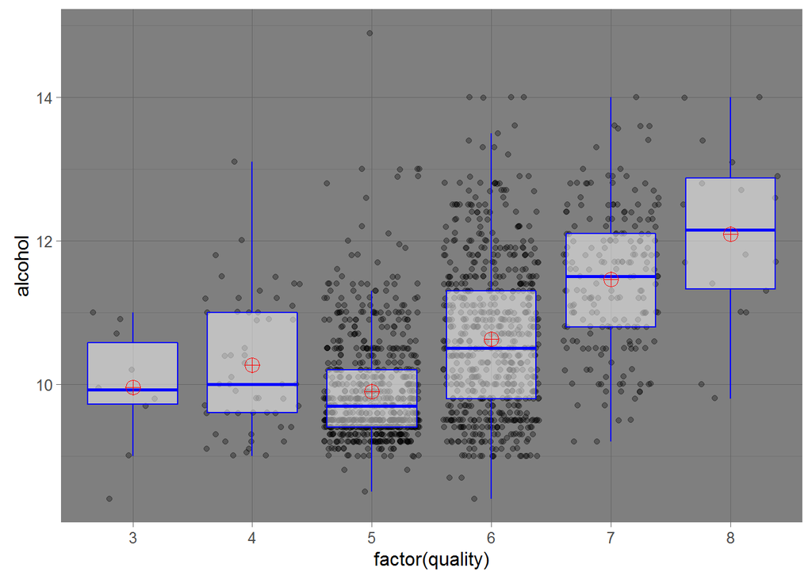

```
##
##  Pearson's product-moment correlation
##
## data:  mydata$quality and mydata$alcohol
## t = 21.639, df = 1597, p-value < 2.2e-16
## alternative hypothesis: true correlation is not equal to 0
## 95 percent confidence interval:
##  0.4373540 0.5132081
## sample estimates:
##       cor
## 0.4761663
```

The boxplot gives us a clearer picture that for higher quality wine, the alcohol content is higher. The correlation is 0.476. For better visualization, let’s plot the median. This can be done by first grouping the dataset according to quality:-

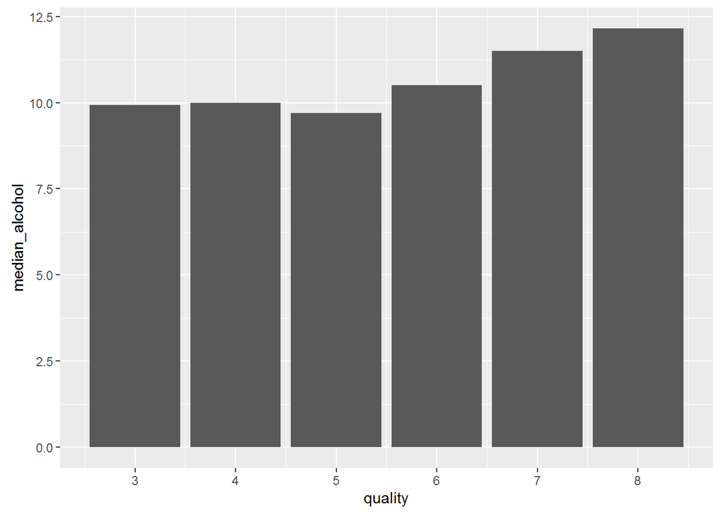

We can repeat the above steps to understand the effect of important factors (based on higher correlation number).

```
## facet_wrap(quality)
```

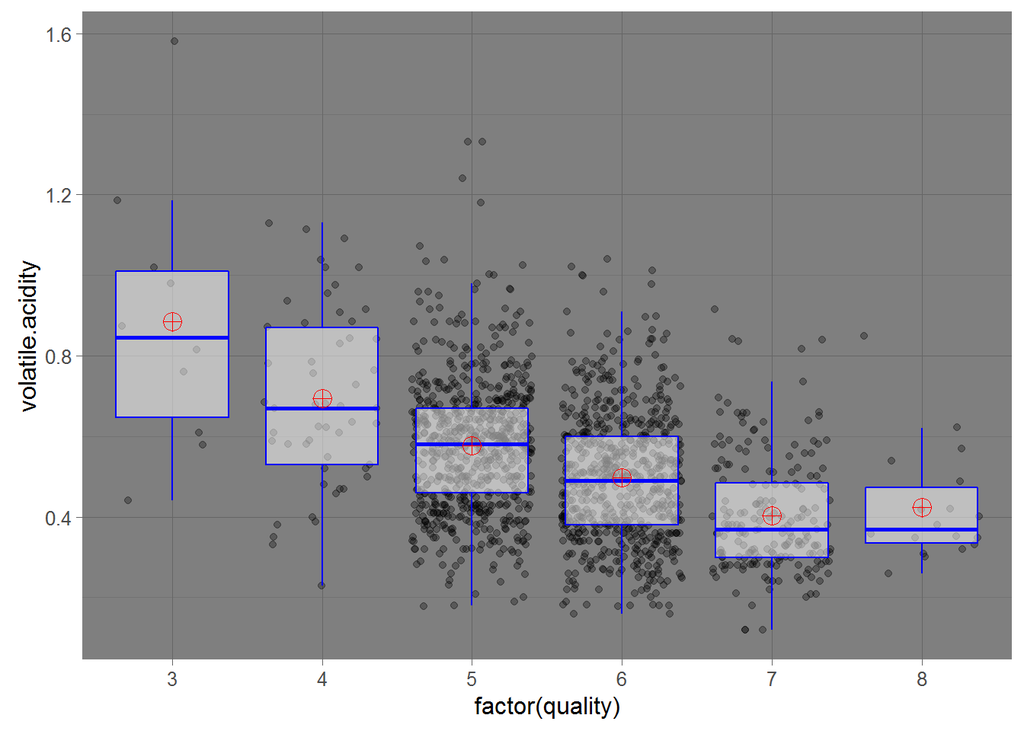

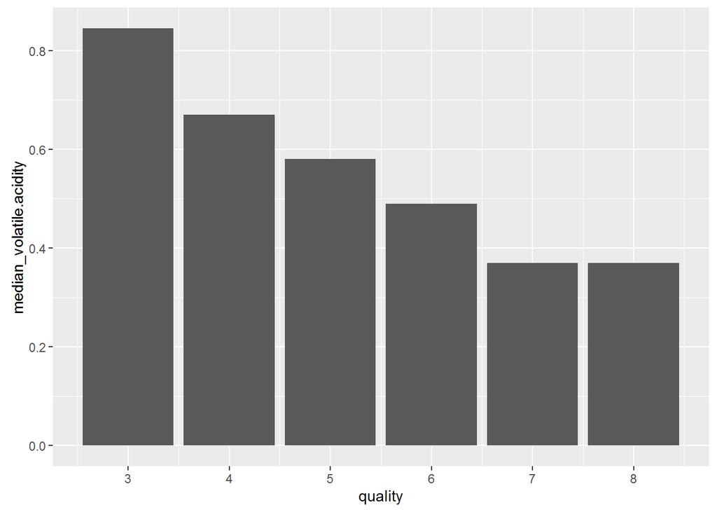

The volatile acidity is lower for wines of higher quality.

```
## facet_wrap(quality)
```

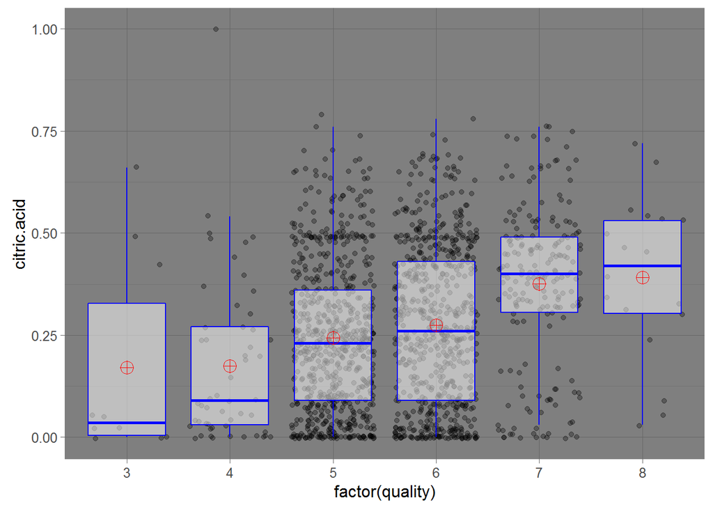

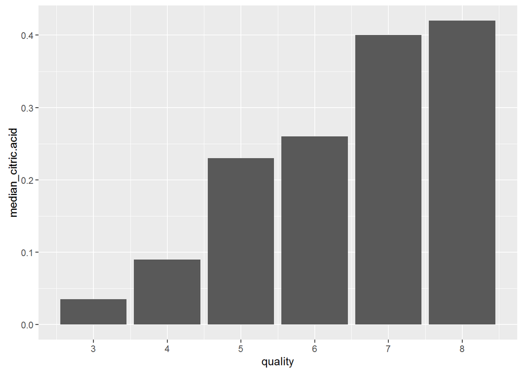

```
##
##  Pearson's product-moment correlation
##
## data:  mydata$citric.acid and mydata$quality
## t = 9.2875, df = 1597, p-value < 2.2e-16
## alternative hypothesis: true correlation is not equal to 0
## 95 percent confidence interval:
##  0.1793415 0.2723711
## sample estimates:
##       cor
## 0.2263725
```

High quality wines have higher quantity of citric acid. Correlation is 0.22

Let’s try to see how the input variables may be related to each other.

[figure not shown]

```
##
##  Pearson's product-moment correlation
##
## data:  mydata$free.sulfur.dioxide and mydata$total.sulfur.dioxide
## t = 35.84, df = 1597, p-value < 2.2e-16
## alternative hypothesis: true correlation is not equal to 0
## 95 percent confidence interval:
##  0.6395786 0.6939740
## sample estimates:
##       cor
## 0.6676665
```

Looks slightly exponential. Correlation is 0.67 which still means they are correlated. This may be due to the fact that total sulfur dioxide contributes to free sulfur dioxide. For the same reason, I comined the two in a single varibale sulfur_dioxide

# Multivariate Plots Section

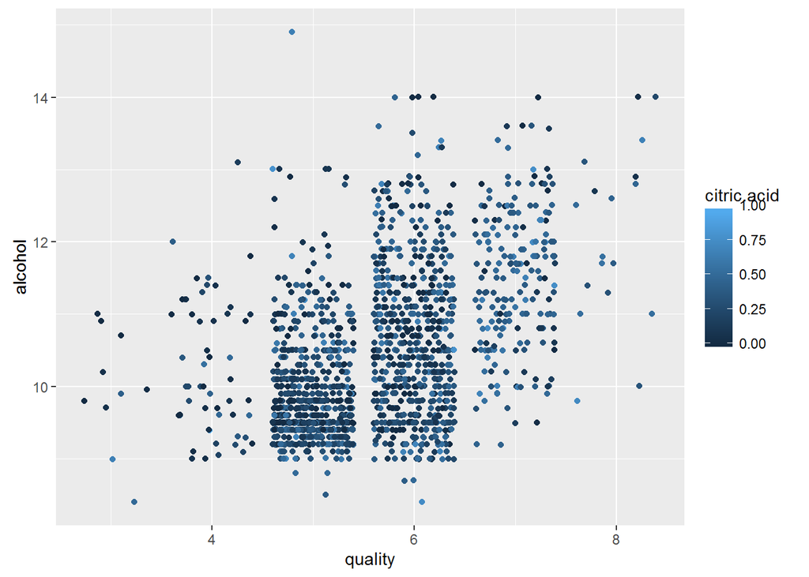

nothing particulary stands out from this plot.

Perhaps, a multivariate plot makes more sense if plotted with a categorical variable. However, our dataset doesn’t have any useful categorical varibale. But we can create one!

I bucketed the alcohol variable to four groups-“Low”, “Medium”, “High”, “Very-High”) based on quantile methods

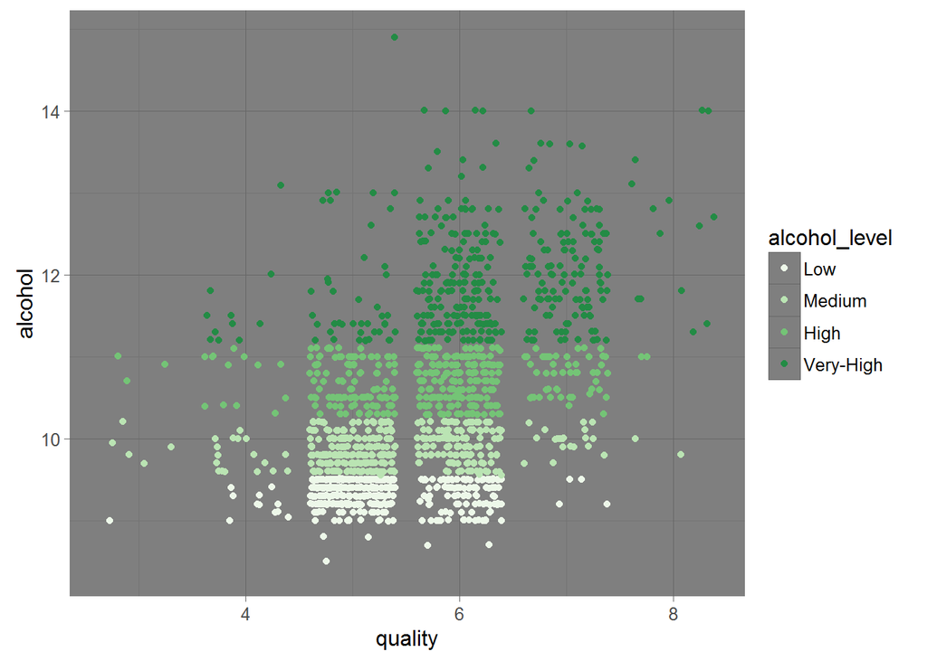

We can see that towards the right side of the plot which has higher quality wine, the alcohol contnt is either high or very high. But we already know this from our bivariate analysis.

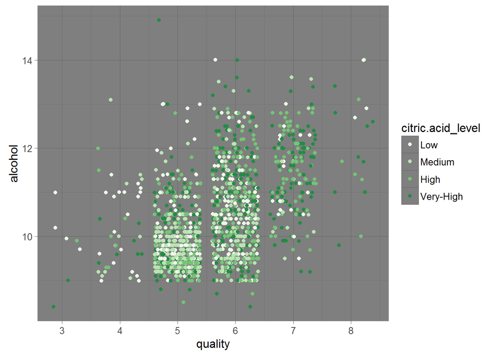

There is nothing conclusive from this plot

Let’s bucket sulphate

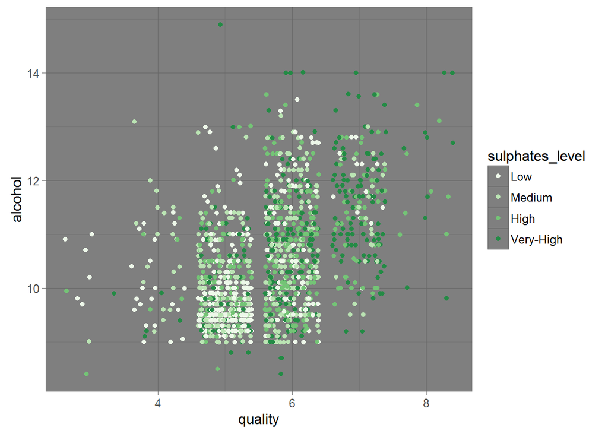

Though this plot is not very conclusive, we can see that the number of low and medium level dots significantly reduce in the high quality dots

Let’s also check for volatile acidity:-

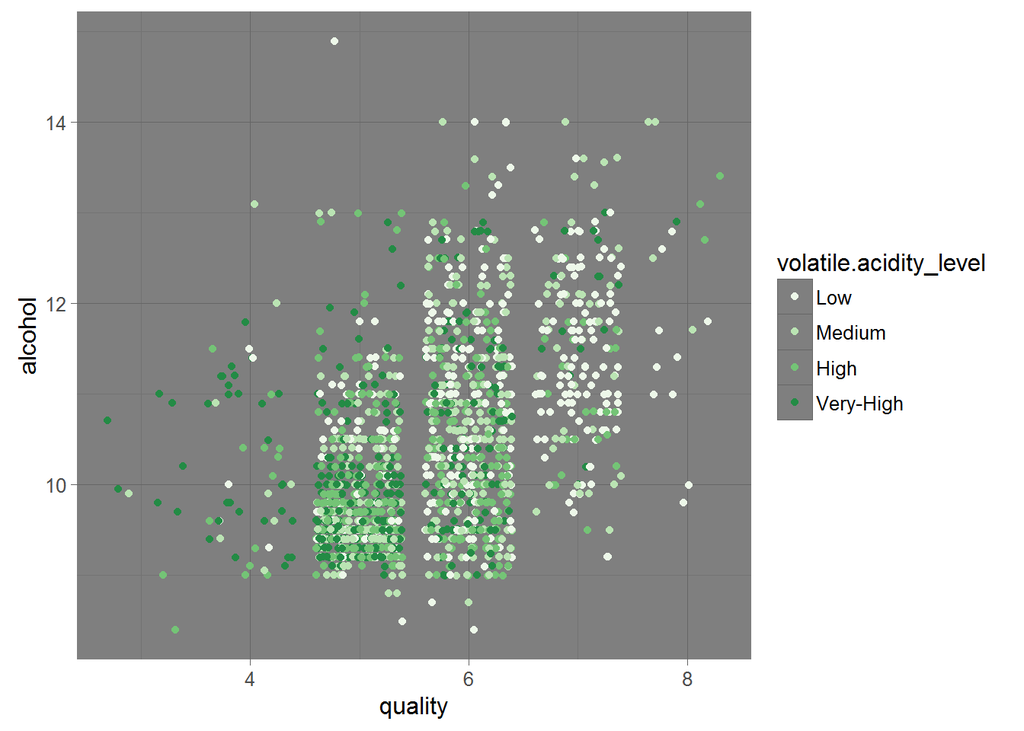

Again from this plot we can only say that the volatile acidity is low for high quality wine.

# Final Plots and Summary

### Plot One: Understanding our dataset in terms of the main feature of interest, quality

```
## <ScaleContinuousPosition>
##  Range:
##  Limits:    3 --    8
```

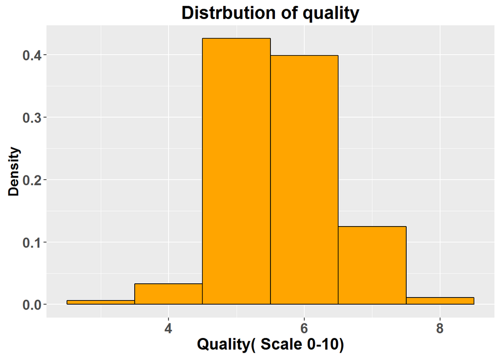

### Description One

Plot one gives us a good insight of the dataset. It tells us that most of the wines are of average quality as the quality score lie between 5-7 on a scale of 0-10. It also tells us that the quality scores lie between 3-8. This information can be used to classify good quality wines and poor quality wines.

### Plot Two: A boxplot showing how alcohol content influences quality of wine

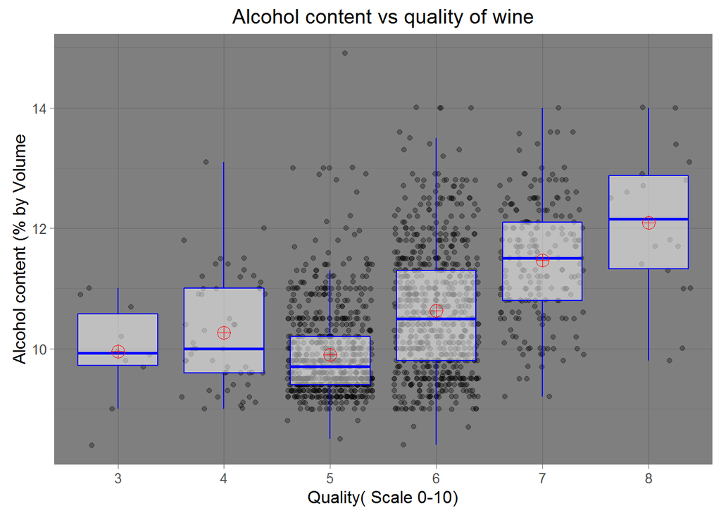

### Plot Three: Check if a thrid variable supports the correlation between alcohol and qaulity and wine

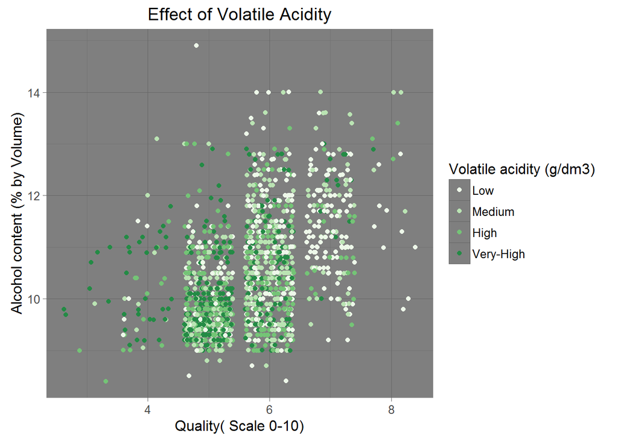

### Description Three

This plot is an attempt to understand if the effect of a thrid variable can be included to support the correlation between two varibales. A categorical variable was created by bucketing the variable volatile acidity using quantile methods into four categories “Low”, “Medium”, “High”, “Very-High”. The reason to pick the volatile acidity is because it is negatively correlated to the quality and hence it would be good to have it on the same plot as a positive factor(alcohol). However, the plot we see here is not very good to draw any strong conclusions about the trend. This tells us that the relation is nonlinear. We can only get a basic idea that the quality of wine improves when the volatile acidity goes down. ——

# Reflection

Overall, this was an interesting data set to work with. We were ineterested in exploring how different input variables influence the output variable-quality. The first important decision I made that helped with the analyses was to find the Pearson correlation of quality with all other variables. This gave an idea of the factors that are contributing most to the quality of wine. These are, alcohol content, volatile acidity, citric acod content and the sulphates content. The main problem I encountered was I wasn’t able to find a strong linear correlation between the varibales. This can be overcome by using support vector machine model as it the best for small data sets with non linear trends. The prodictive model would greatly enhance the quality of data analysis and I would like to work on it in the future.